# 人口集中地区データによる郊外化の可視化

高松市，富山市，熊本市の例

[岩田真一郎](https://shinichiro-iwata.github.io/)（ [神奈川大学経済学部](https://www.econ.kanagawa-u.ac.jp/)）

2022-06-12作成，2024-03-13改訂

# 目的

国土数値情報のDID人口集中地区（ポリゴン）を利用して地方都市の郊外化を可視化．

- 地方都市ではモータリゼーションの進展とそれに伴い市街地が外延．
- 郊外化を示す方法の一つして，人口が集まっている地域，人口集中地区（[DID](https://ja.wikipedia.org/wiki/%E4%BA%BA%E5%8F%A3%E9%9B%86%E4%B8%AD%E5%9C%B0%E5%8C%BA)：Densely inhabited districtの略），の面積の拡大によって示す方法がある．
  - 実際に，内閣府により認定された地方都市の[中心市街地活性化基本計画](https://www.chisou.go.jp/tiiki/chukatu/nintei.html)には郊外化の現状を人口集中地区面積の増大や，人口集中地区の人口密度の低下を用いて示している．
  - ここでは，香川県高松市の第3期[高松市中心市街地活性化計画](https://www.city.takamatsu.kagawa.jp/kurashi/shinotorikumi/machidukuri/kasseika/chushin/index.html)（アクセス日：2022/06/09）の第1章7頁の 図「[DID区域の変遷](https://www.city.takamatsu.kagawa.jp/kurashi/shinotorikumi/machidukuri/kasseika/chushin/3rd.files/section1.pdf)」（アクセス日：2022/06/09）を参考に1975年と2015年の人口集中地区の地図を重ね，その変換を可視化．
  - 高松市，富山県富山市（第1期[富山市中心市街地活性化計画](https://www.city.toyama.toyama.jp/katsuryokutoshisouzoubu/machidukuri/chushinshigaichi.html)（アクセス日：2022/06/09）は2007年2月8日に内閣総理大臣から最初に認定された），政令指定都市の熊本県熊本市を取り上げる．熊本市も[熊本市中心市街地活性化計画（熊本地区）](https://www.city.kumamoto.jp/hpKiji/pub/detail.aspx?c_id=5&id=806&class_set_id=2&class_id=2628)（アクセス日：2022/06/09）が認定されている．

ライブラリ：`sf`，`tidyverse`

```r
library(sf)
library(tidyverse)
```

# 高松市の人口集中地区の可視化

**シェープファイルのダウンロード**

- [国土数値情報ダウンロードサービス](https://nlftp.mlit.go.jp/ksj/) > 行政区域（ポリゴン） > 香川県 > 令和3年
  - ダウンロードしたZIPファイルは同じフォルダ（ディレクトリ）に納め，ZIPファイルを選択 > 右クリック > すべて展開 > 展開先の選択とファイルの選択 > 展開を実行する．展開後は最初にダウンロードしたZIPファイルを削除．
  - `read_sf`：データ読込．`Kagawa_map`と名付ける．
  - `Kagawa_map`から高松市（行政区域コード`N03_007`の`37201`）を切り抜き，新しいデータを`Takamatsu_shi_map`とする．

```r
Kagawa_map <-
  read_sf("N03-20210101_37_GML/N03-21_37_210101.shp")

#高松市選別
Kagawa_map %>%
  filter(N03_007=="37201") ->
  Takamatsu_shi_map
```

時系列の変化を見るため，例として1975年（昭和50年）と2015年（平成27年）の人口集中地区のシェープファイルをダウンロードする．

- [国土数値情報ダウンロードサービス](https://nlftp.mlit.go.jp/ksj/) > DID人口集中地区（ポリゴン） > 香川県 > 世界測地系 昭和50年（および平成27年）
  - ダウンロードしたZIPファイルは同じフォルダ（ディレクトリ）に納め，ZIPファイルを選択 > 右クリック > すべて展開 > 展開先の選択とファイルの選択 > 展開を実行する．展開後は最初にダウンロードしたZIPファイルを削除．．
  - `read_sf`：データ読込．`Kagawa_DID75`，`Kagawa_DID15`と名付ける．
  - `crs="WGS84"`は`crs`（Coordinate ReferenceSystem，座標参照系）を1984年に定められた世界測地系(World Geodetic System)に投影を意味．この指示をしないとエラーが出現．
  - `Kagawa_DID#`（`#`は`75`か`15`）から高松市（行政区域コード`A16_002`の`37201`）を切り抜き，新しいデータを`Takamatsu_shi_DID#`とする．

```r
#1975年の人口集中地区データの読込
Kagawa_DID75 <-
  read_sf("A16-75_37_GML/A16-75_37_DID.shp",
                      crs="WGS84")

#高松市選別
Kagawa_DID75 %>%
  filter(A16_002=="37201") ->
  Takamatsu_shi_DID75
```

```r
#2015年の人口集中地区データの読込
Kagawa_DID15 <-
  read_sf("A16-15_37_GML/A16-15_37_GML/A16-15_37_DID.shp",
                      crs="WGS84")

#高松市選別
Kagawa_DID15 %>%
  filter(A16_002=="37201") ->
  Takamatsu_shi_DID15
```

地図上に鉄道（ライン）を可視化．

- [国土数値情報ダウンロードサービス](https://nlftp.mlit.go.jp/ksj/) > 鉄道（ライン） > 全国 > 世界測地系 > 令和2年
  - 鉄道データは全国のみ．
  - ダウンロードしたZIPファイルは同じディレクトリに納め，ZIPファイルを選択 > 右クリック > 解凍 > ここで解凍 を実行する．解凍後は最初にダウンロードしたZIPファイルを削除．
  - `railway20`と名付ける．

```r
railway20 <-
  read_sf("N02-20_GML/N02-20_GML/N02-20_RailroadSection.shp")
```

**人口集中地区の可視化**

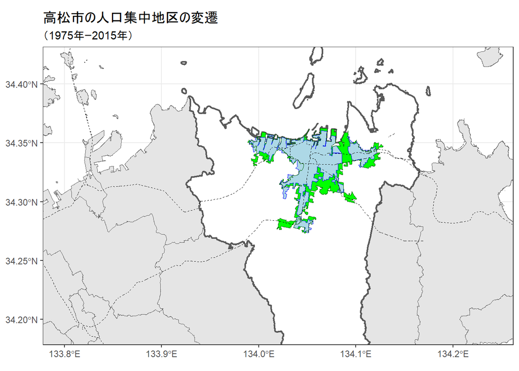

```r
ggplot()+
  geom_sf(data=Kagawa_map)+
  geom_sf(data=Takamatsu_shi_map, fill="white",
          linewidth=0.8)+
  geom_sf(data=Takamatsu_shi_DID15,
          fill="green", color="darkgreen")+
  geom_sf(data=Takamatsu_shi_DID75,
          fill="lightblue", color="blue")+
  geom_sf(data=Takamatsu_shi_DID15, fill="NA",
          color="darkgreen")+
  geom_sf(data=railway20, linewidth=0.2,
          linetype="dashed")+
  coord_sf(xlim=c(133.80, 134.24),
           ylim=c(34.19, 34.42))+
  ggtitle("高松市の人口集中地区の変遷",
          subtitle="（1975年ｰ2015年）")+
  theme_bw()
```

**凡例の作成と完成図**

1975年と2015年の人口集中地区の凡例を作成．

- ↑の地図との違い．
  - 人口集中地区の境界内の色と境界線と色を`aes()`で指示．
  - `scale_fill_manual()`と`scale_color_manual()`を用いて手動で境界内の色と境界線と色を指示．色を除く内容を揃えることで，凡例を一つにまとめる．
  - `labs()`内に出典表記（`caption`）．

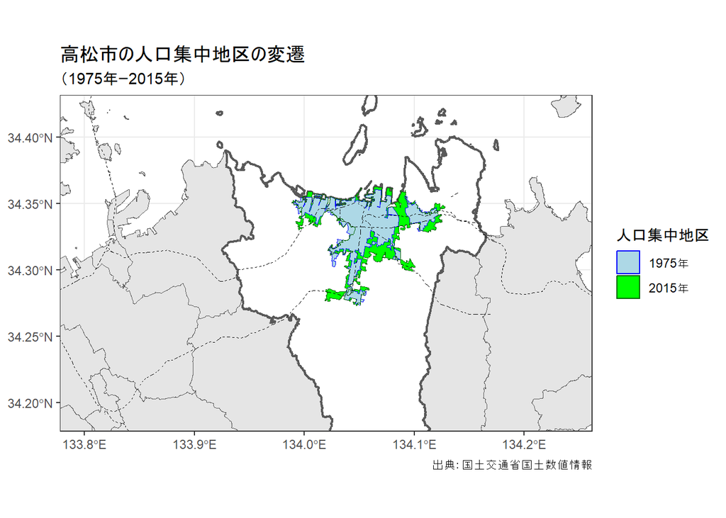

```r
#凡例の作成
ggplot()+
  geom_sf(data=Kagawa_map)+
  geom_sf(data=Takamatsu_shi_map, fill="white",
          linewidth=0.8)+
  geom_sf(data=Takamatsu_shi_DID15,
          aes(fill="2015年", color="2015年"))+
  geom_sf(data=Takamatsu_shi_DID75,
          aes(fill="1975年", color="1975年"))+
  scale_fill_manual(name="人口集中地区",
                    labels=c("1975年", "2015年"),
                    values=c("lightblue", "green"))+
  scale_color_manual(name="人口集中地区",
                     labels=c("1975年", "2015年"),
                     values=c("blue", "darkgreen"))+
  geom_sf(data=Takamatsu_shi_DID15, fill="NA",
          color="dark green")+
  geom_sf(data=railway20, linewidth=0.2,
          linetype="dashed")+
  labs(caption="出典：国土交通省国土数値情報")+
  coord_sf(xlim=c(133.80, 134.24),
           ylim=c(34.19, 34.42))+
  ggtitle("高松市の人口集中地区の変遷",
          subtitle="（1975年ｰ2015年）")+
  theme_bw()
```

**参考（高松市DID人口密度）**

↑で利用したDID人口集中地区のデータには人口集中地区の人口（人）や面積（㎢）が示されている．この数値から人口密度（人／㎢）が計算できる．

- 1975年と2015年の人口，面積，人口密度を表にまとめる．

高松市の人口集中地区人口密度（人／㎢）

| 年 | 人口 | 面積 | 人口密度 |
| --- | --- | --- | --- |
| 1975 | 179426 | 29.40 | 6102.925 |
| 2015 | 212897 | 41.04 | 5187.549 |

# 富山市の人口集中地区の可視化

同じ作業のため，コードは記さない．

- **注意**：1975年は市町村合併前のため，富山県婦負郡八尾町が富山市の行政区域コード（`A16_002`）と異なる．そこで，富山市（`16201`）だけでなく八尾町（`16361`）も含めて，1975年の富山市の人口集中地区データを作成．
  - 2015年には，この地区は人口集中地区の要件を満たしていない．↓の地図参照．

```r
Toyama_DID75 %>%
  filter(A16_002=="16201" | A16_002=="16361") ->
  Toyama_shi_DID75
```

**人口集中地区の可視化**

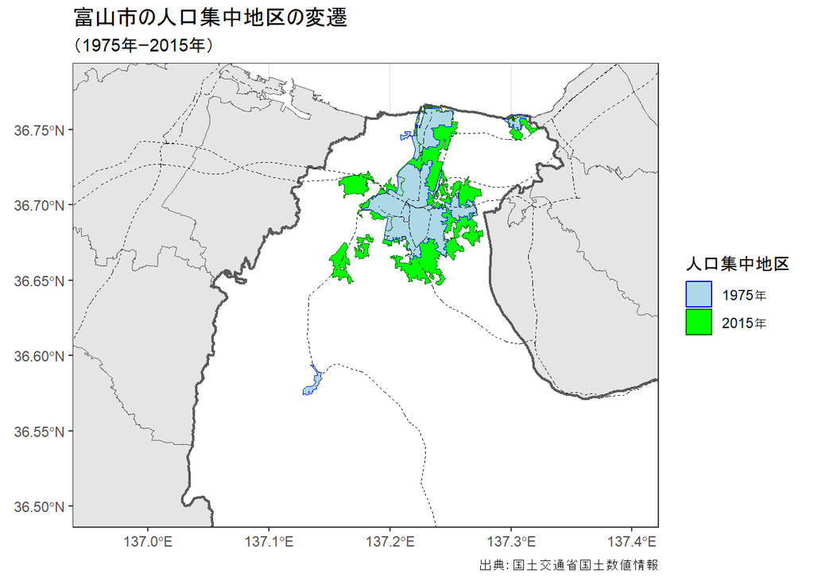

**参考（富山市DID人口密度）**

富山市の人口集中地区人口密度（人／㎢）

| 年 | 人口 | 面積 | 人口密度 |
| --- | --- | --- | --- |
| 1975 | 166572 | 32.00 | 5205.375 |
| 2015 | 235868 | 57.89 | 4074.417 |

# 熊本市の人口集中地区の可視化

同じ作業のため，コードは記さない．

- ただし，2012年度から政令指定都市になったため，行政区域のコードに注意すること．
- **注意**：2015年は行政区域コード（`A16_002`）の`43101`から`43105`が熊本市．

```r
Kumamoto_DID15 %>%
  filter(A16_002>="43101" & A16_002<="43105") ->
  Kumamoto_shi_DID15
```

**人口集中地区の可視化**

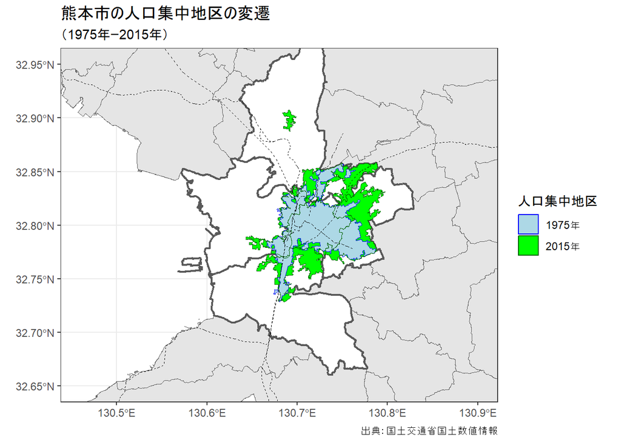

**注意**：熊本市北部に2015年に1975年には存在しなかった人口集中地区が加わっている．この地区は[熊本市中心市街地活性化基本計画（植木地区）](https://www.city.kumamoto.jp/hpKiji/pub/detail.aspx?c_id=5&id=1545&class_set_id=3&class_id=663)（アクセス日：2022/06/09）により別途認定．

**参考（熊本市DID人口密度）**

熊本市の人口集中地区人口密度（人／㎢）

| 年 | 人口 | 面積 | 人口密度 |
| --- | --- | --- | --- |
| 1975 | 379589 | 51.00 | 7442.922 |
| 2015 | 587816 | 88.76 | 6622.533 |

**Rによる地理空間データの可視化**

- チュートリアル[ホーム](https://shinichiro-iwata.github.io/geospatial-data-visualization/)